# Initial Modeling

```r
track <- read.csv("track_dist.csv")
```

### Notes on this document

We made 11 separate models in this document to see how the data could be modeled. Depending on a few questions we have, our final model will be either Model 9, Model 10, or Model 11.

**Model 9**  
Here, we use centered variables on original scales. As predictors, we include distance (quantitative, 100m Dash = 0), centered BMI, sex, year (0 = 1896), centered GDP (in $Billions), and interactions between distance*BMI, distance*sex, and distance*GDP. We are treating level 1 as the individual athletes and level 2 as the countries they represent.

We ran into a few issues with the scaling of factors, namely distance and time in seconds (response). Each event is on a drastically different scale, since athletes compete in events of distances 100m, 200m, 400m, 800m, 5k. In later models we used a log transformation on these variables.

**Model 10**  
Here, we used the same model as Model 9, except that distance has now undergone a log transformation. However, when we plug in values for a male running the 100m dash, the expected completion time is -615 seconds, which doesn’t make sense.

**Model 11**  
Here, we used the same model as model 10, but now our response, time in seconds, has undergone a log transformation as well. This resulted in centered BMI, logdist100:c_BMI, and logdist100:sexW no longer being significant. However, this did a better job at predicting an average male’s 100m dash time at 2.46 log(seconds) = $e^2.46$ = 11.72 seconds. This makes a lot more sense now.

**Next Steps:**  
Since AIC/BIC are not effective in comparing these models, we will be looking at residual plots to decide which of these to use.

### Model 1 = Random Intercepts

```r
mod1 <- lme(data = track, fixed = timeSecs ~ 1, random = ~1|country2)
mod1
```

```
Linear mixed-effects model fit by REML
  Data: track
  Log-restricted-likelihood: -4394.977
  Fixed: timeSecs ~ 1
(Intercept)
   423.1011

Random effects:
 Formula: ~1 | country2
        (Intercept) Residual
StdDev:    383.6371 419.2617

Number of Observations: 585
Number of Groups: 45
```

```r
print(VarCorr(mod1), comp=c("Variance", "Std.Dev."), digits = 2)
```

```
country2 = pdLogChol(1)
            Variance StdDev
(Intercept) 147177.4 383.6371
Residual    175780.4 419.2617
```

ICC = 147177.4/(147177.4+175780.4) = 0.456 45.6% of the variation in finishing times is due to country-to-country variation. If we randomly selected two athletes from the same country, their finishing times would be 45.6% correlated.

Intercept: The average finishing time of an athlete from the average country is 7.052 minutes.

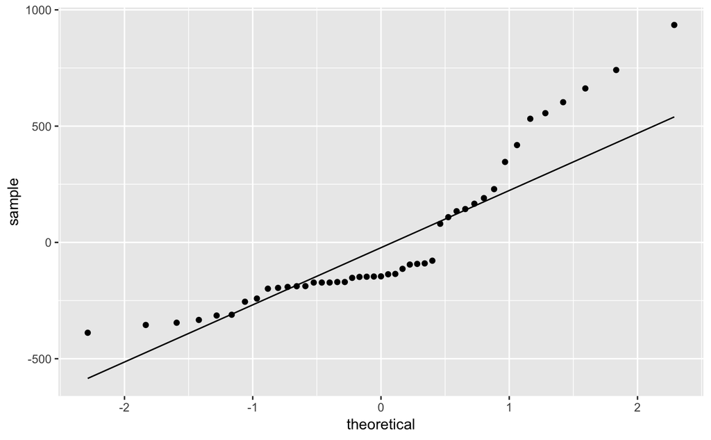

```r
ggplot(ranef(mod1),aes(sample = ranef(mod1)[,1]) ) + stat_qq() + stat_qq_line()
```

We might have some caution with the model since the random effects are not approximately normal, but we will procede with this in mind.

### Mode1 2 = Random Intercepts + fixed effect distance

```r
mod2 <- lme(data = track, fixed = timeSecs ~ dist, random = ~1|country2)
mod2
```

```
Linear mixed-effects model fit by REML
  Data: track
  Log-restricted-likelihood: -2957.623
  Fixed: timeSecs ~ dist
(Intercept)        dist
-24.2852599   0.1771274

Random effects:
 Formula: ~1 | country2
        (Intercept) Residual
StdDev:    16.42762 36.54942

Number of Observations: 585
Number of Groups: 45
```

```r
print(VarCorr(mod2), comp=c("Variance", "Std.Dev."), digits = 2)
```

```
country2 = pdLogChol(1)
            Variance  StdDev
(Intercept)  269.8667 16.42762
Residual    1335.8604 36.54942
```

Both variances went down extremely. The within country variation went from $\sigma^2 = 175780.4$ to $\sigma^2 = 1335.9$, decreasing it by 99.2%. After adjusting for the distance of the race, our ICC went down to 16.8%. If we randomly selected two athletes from the same country, their finishing times would be 16.8% correlated, after adjusting for the distance of their race.

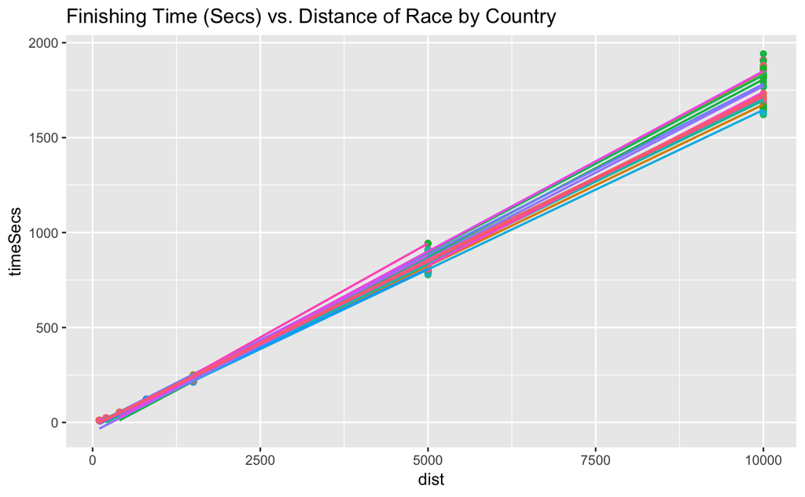

```r
ggplot(data = track, aes(y = timeSecs, x = dist, col = country2)) + geom_point(show.legend = F) + geom_smooth(method="lm", show.legend = F, se = F, size = .7) + ggtitle("Finishing Time (Secs) vs. Distance of Race by Country")
```

### Model 3 = Random Intercepts, Random Slopes for distance

```r
mod3 <- lme(data = track, fixed = timeSecs ~ dist, random = ~ dist|country2)
mod3
```

```
Linear mixed-effects model fit by REML
  Data: track
  Log-restricted-likelihood: -2910.962
  Fixed: timeSecs ~ dist
(Intercept)        dist
-23.2630898   0.1754018

Random effects:
 Formula: ~dist | country2
 Structure: General positive-definite, Log-Cholesky parametrization
            StdDev       Corr
(Intercept)  8.232628737 (Intr)
dist         0.007090814 -0.776
Residual    33.256101511

Number of Observations: 585
Number of Groups: 45
```

```r
print(VarCorr(mod3), comp=c("Variance", "Std.Dev."), digits = 2)
```

```
country2 = pdLogChol(dist)
            Variance     StdDev       Corr
(Intercept) 6.777618e+01  8.232628737 (Intr)
dist        5.027964e-05  0.007090814 -0.776
Residual    1.105968e+03 33.256101511
```

There was a $\frac{1335.8604-1105.968}{1335.8604} *100 = 17.2\%$ decrease in $\sigma^2$, within country variation, by allowing random slopes for distance by country.

```r
anova(mod2,mod3)
```

|  | Model | df | AIC | BIC | logLik | Test | L.Ratio | p-value |
| --- | --- | --- | --- | --- | --- | --- | --- | --- |
| mod2 | 1 | 4 | 5923.246 | 5940.718 | -2957.623 |  |  |  |
| mod3 | 2 | 6 | 5833.925 | 5860.134 | -2910.962 | 1 vs 2 | 93.3209 | <.0001 |

Random slopes for distance makes the model significantly better. The relationship between time and distance is different country to country (every 1 meter increase corresponds to a different increase in finishing time depending on the country).

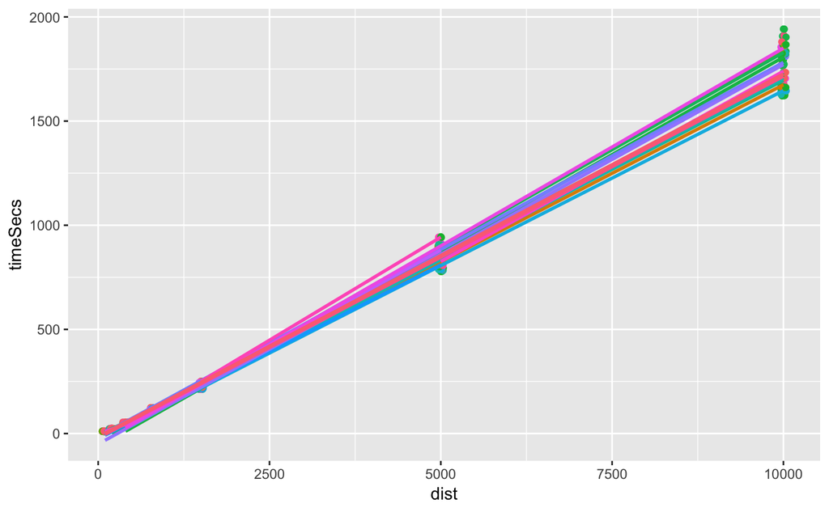

```r
ggplot(data = track, aes(x=dist, y = timeSecs, color = country2)) + geom_point(show.legend = F) + geom_jitter(height = .5, show.legend = F) + geom_smooth(method = "lm", se = F, show.legend = F)
```

Model building steps: First, we fit a random intercepts model treating country as random level 2 units. Next, we added distance as a fixed effect because there will obviously be a lot of variation in finishing times due to distance. Then we reassessed our more accurate ICC. Then, we allowed the slopes for distance to be random across country. This was helpful in explaining within country variation. Now we will fit a model with all the fixed effects our EDA indicated would be useful in explaining finishing times. After looking at that, we will assess and systematically remove the largest non-signficant terms one by one.

Fixed effects to add from EDA: - distance,height, weight, height x distance, weight x distance, year, age, age x year, age x dist, sex, sex x dist, GDP, logPOP -keep in mind height and weigt are very correlated (could try BMI = weight/(height^2)) and gdp and logPOP are very correlated (could try GDP/capita = GDP/POP) and gdp and year are correlated

```r
track <- track %>% select(timeSecs, timeMins, name, event, country2, country, medal, city, sex,                               medal, year, dist, age, height, weight, gdp, pop) %>%
                   mutate(
                      year1896 = year - 1896,
                      dist100 = dist - 100,
                      logpop = log(pop),
                      c_age = scale(age)[,1],
                      c_height = scale(height)[,1],
                      c_weight = scale(weight)[,1],
                      c_gdp = scale(gdp)[,1],
                      c_pop = scale(pop)[,1],
                      c_logpop = scale(logpop)[,1],
                      gdpbillion = gdp/1000000000,
                      c_gdpbillion = scale(gdpbillion)[,1],
                      BMI = weight / (height/100)^2,
                      c_BMI = scale(BMI)[,1],
                      gdp_pop = gdp/pop,
                      c_gdp_pop = scale(gdp_pop)[,1]
               )
```

### Model 4

```r
mod4 <- lme(data = track,
            fixed = timeSecs ~ dist100 + c_height + c_weight + c_height*dist100 + c_weight*dist100 +
                               year1896 + c_age + c_age*year1896 + c_age*dist100 + sex + sex*dist100                                + c_logpop + c_gdp,
            random = ~ dist100|country2)
summary(mod4)
```

```
Linear mixed-effects model fit by REML
 Data: track
```

|  | AIC | BIC | logLik |
| --- | --- | --- | --- |
|  | 5323.445 | 5401.698 | -2643.722 |

```
Random effects:
 Formula: ~dist100 | country2
 Structure: General positive-definite, Log-Cholesky parametrization
            StdDev       Corr
(Intercept) 11.300150100 (Intr)
dist100      0.006714674 -0.942
Residual    20.009734766

Fixed effects: timeSecs ~ dist100 + c_height + c_weight + c_height * dist100 +      c_weight * dist100 + year1896 + c_age + c_age * year1896 +      c_age * dist100 + sex + sex * dist100 + c_logpop + c_gdp
```

|  | Value | Std.Error | DF | t-value | p-value |
| --- | --- | --- | --- | --- | --- |
| (Intercept) | 17.889705 | 4.271045 | 527 | 4.18860 | 0.0000 |
| dist100 | 0.171779 | 0.001433 | 527 | 119.91080 | 0.0000 |
| c_height | -0.022202 | 1.825382 | 527 | -0.01216 | 0.9903 |
| c_weight | 6.681171 | 2.034559 | 527 | 3.28384 | 0.0011 |
| year1896 | -0.395314 | 0.042379 | 527 | -9.32796 | 0.0000 |
| c_age | 1.198796 | 2.740630 | 527 | 0.43742 | 0.6620 |
| sexW | 20.109938 | 3.436543 | 527 | 5.85179 | 0.0000 |
| c_logpop | -1.245292 | 1.770208 | 527 | -0.70347 | 0.4821 |
| c_gdp | 6.158151 | 1.415637 | 527 | 4.35009 | 0.0000 |
| dist100:c_height | -0.004209 | 0.000558 | 527 | -7.54313 | 0.0000 |

[output cut: 4 more lines]

```
 Correlation:
                 (Intr) dst100 c_hght c_wght yr1896 c_age  sexW   c_lgpp c_gdp  dst100:c_h dst100:c_w y1896: dst100:c_g
dist100          -0.557
c_height         -0.018 -0.010
c_weight         -0.054  0.083 -0.649
year1896         -0.736  0.053 -0.057 -0.086
c_age             0.201 -0.035 -0.073  0.073 -0.242
sexW             -0.045  0.115  0.181  0.394 -0.334  0.125
c_logpop          0.168 -0.118 -0.084  0.083 -0.037  0.106 -0.059
c_gdp             0.412 -0.019  0.120 -0.174 -0.483 -0.088 -0.014 -0.360
dist100:c_height  0.086 -0.012 -0.461  0.352 -0.139  0.080  0.035 -0.006 -0.007
dist100:c_weight -0.114  0.117  0.224 -0.430  0.187 -0.095 -0.261  0.004  0.021 -0.612
year1896:c_age   -0.174  0.032  0.078 -0.055  0.199 -0.915 -0.101 -0.071  0.053 -0.062      0.075
dist100:c_age    -0.063 -0.058  0.033 -0.076  0.115 -0.269 -0.086 -0.034  0.034 -0.088      0.080      0.048
dist100:sexW      0.021  0.011 -0.075 -0.204  0.078 -0.030 -0.450 -0.029  0.060  0.063      0.531      0.011  0.022

Standardized Within-Group Residuals:
         Min           Q1          Med           Q3          Max
-4.959872437 -0.434931695 -0.007872736  0.374403693  8.056420510

Number of Observations: 585
Number of Groups: 45
```

### Model 5

```r
mod5 <- lme(data = track,
            fixed = timeSecs ~ dist100 + c_BMI + c_BMI*dist100 +
                               year1896 + c_age + c_age*year1896 + c_age*dist100 + sex +
                               sex*dist100 + c_gdp_pop,
            random = ~ dist100|country2)
summary(mod5)
```

```
Linear mixed-effects model fit by REML
 Data: track
```

|  | AIC | BIC | logLik |
| --- | --- | --- | --- |
|  | 5370.394 | 5435.684 | -2670.197 |

```
Random effects:
 Formula: ~dist100 | country2
 Structure: General positive-definite, Log-Cholesky parametrization
            StdDev       Corr
(Intercept) 11.470258780 (Intr)
dist100      0.007089808 -0.933
Residual    21.011535363

Fixed effects: timeSecs ~ dist100 + c_BMI + c_BMI * dist100 + year1896 + c_age +      c_age * year1896 + c_age * dist100 + sex + sex * dist100 +      c_gdp_pop
```

|  | Value | Std.Error | DF | t-value | p-value |
| --- | --- | --- | --- | --- | --- |
| (Intercept) | 13.478959 | 4.527568 | 530 | 2.97709 | 0.0030 |
| dist100 | 0.172492 | 0.001486 | 530 | 116.08043 | 0.0000 |
| c_BMI | 4.333177 | 1.330373 | 530 | 3.25711 | 0.0012 |
| year1896 | -0.348624 | 0.048044 | 530 | -7.25629 | 0.0000 |
| c_age | 2.225986 | 2.856117 | 530 | 0.77937 | 0.4361 |
| sexW | 14.693626 | 2.903846 | 530 | 5.06006 | 0.0000 |
| c_gdp_pop | 3.002130 | 1.488306 | 530 | 2.01715 | 0.0442 |
| dist100:c_BMI | 0.002016 | 0.000483 | 530 | 4.17592 | 0.0000 |
| year1896:c_age | -0.040038 | 0.032112 | 530 | -1.24683 | 0.2130 |
| dist100:c_age | 0.000289 | 0.000280 | 530 | 1.03089 | 0.3031 |

[output cut: 1 more lines]

```
 Correlation:
               (Intr) dst100 c_BMI  yr1896 c_age  sexW   c_gdp_ d100:_B y1896: ds100:_
dist100        -0.511
c_BMI          -0.117  0.102
year1896       -0.792  0.057 -0.001
c_age           0.211 -0.020  0.052 -0.258
sexW           -0.015  0.092  0.463 -0.255  0.181
c_gdp_pop       0.564 -0.056 -0.191 -0.645  0.009 -0.056
dist100:c_BMI  -0.076  0.058 -0.457  0.141 -0.090 -0.293  0.051
year1896:c_age -0.194  0.018 -0.037  0.232 -0.915 -0.166 -0.044  0.065
dist100:c_age  -0.068 -0.055 -0.067  0.107 -0.268 -0.087  0.002  0.092   0.047
dist100:sexW    0.042 -0.068 -0.236  0.061 -0.034 -0.477  0.067  0.556   0.008  0.050

Standardized Within-Group Residuals:
         Min           Q1          Med           Q3          Max
-5.189647914 -0.444364689 -0.005206271  0.374535646  8.375570994

Number of Observations: 585
Number of Groups: 45
```

Looks like all the terms with age are statistically insignificant (age, year x age, distance x age) So, next we will remove them and refit the model.

### Model 6

```r
mod6 <- lme(data = track,
            fixed = timeSecs ~ dist100 + c_BMI + c_BMI*dist100 +
                               year1896 + sex +
                               sex*dist100 + c_gdp_pop,
            random = ~ dist100|country2)
summary(mod6)
```

```
Linear mixed-effects model fit by REML
 Data: track
```

|  | AIC | BIC | logLik |
| --- | --- | --- | --- |
|  | 5349.475 | 5401.769 | -2662.738 |

```
Random effects:
 Formula: ~dist100 | country2
 Structure: General positive-definite, Log-Cholesky parametrization
            StdDev      Corr
(Intercept) 11.48201198 (Intr)
dist100      0.00717439 -0.933
Residual    20.99959247

Fixed effects: timeSecs ~ dist100 + c_BMI + c_BMI * dist100 + year1896 + sex +      sex * dist100 + c_gdp_pop
```

|  | Value | Std.Error | DF | t-value | p-value |
| --- | --- | --- | --- | --- | --- |
| (Intercept) | 12.748961 | 4.428559 | 533 | 2.87881 | 0.0042 |
| dist100 | 0.172547 | 0.001497 | 533 | 115.23479 | 0.0000 |
| c_BMI | 4.365171 | 1.325862 | 533 | 3.29233 | 0.0011 |
| year1896 | -0.340366 | 0.046405 | 533 | -7.33475 | 0.0000 |
| sexW | 14.362158 | 2.851198 | 533 | 5.03724 | 0.0000 |
| c_gdp_pop | 2.859676 | 1.481910 | 533 | 1.92972 | 0.0542 |
| dist100:c_BMI | 0.002002 | 0.000480 | 533 | 4.17515 | 0.0000 |
| dist100:sexW | 0.019127 | 0.000902 | 533 | 21.19741 | 0.0000 |

```
 Correlation:
              (Intr) dst100 c_BMI  yr1896 sexW   c_gdp_ d100:_
dist100       -0.522
c_BMI         -0.133  0.100
year1896      -0.781  0.057  0.015
sexW          -0.056  0.093  0.460 -0.217
c_gdp_pop      0.578 -0.060 -0.193 -0.669 -0.061
dist100:c_BMI -0.057  0.060 -0.452  0.119 -0.281  0.052
dist100:sexW   0.050 -0.068 -0.233  0.053 -0.480  0.063  0.555

Standardized Within-Group Residuals:
       Min         Q1        Med         Q3        Max
-5.2576587 -0.4374543 -0.0124798  0.3836700  8.4847422

Number of Observations: 585
Number of Groups: 45
```

GDP/pop is slightly insignificant (p-value = 0.0542). From the EDA and model 4, we saw that GDP had a relationship with finishing time. And model 4 showed that populatio (logpop) doesn’t have a significant relationship with finishing time. So we are going to replace GDP/pop with GDP.

### Model 7

```r
mod7 <- lme(data = track,
            fixed = timeSecs ~ dist100 + c_BMI + c_BMI*dist100 +
                               year1896 + sex +
                               sex*dist100 + c_gdp,
            random = ~ dist100|country2)
summary(mod7)
```

```
Linear mixed-effects model fit by REML
 Data: track
```

|  | AIC | BIC | logLik |
| --- | --- | --- | --- |
|  | 5335.141 | 5387.435 | -2655.57 |

```
Random effects:
 Formula: ~dist100 | country2
 Structure: General positive-definite, Log-Cholesky parametrization
            StdDev      Corr
(Intercept) 12.19196725 (Intr)
dist100      0.00725988 -0.933
Residual    20.69122960

Fixed effects: timeSecs ~ dist100 + c_BMI + c_BMI * dist100 + year1896 + sex +      sex * dist100 + c_gdp
```

|  | Value | Std.Error | DF | t-value | p-value |
| --- | --- | --- | --- | --- | --- |
| (Intercept) | 18.262589 | 4.393242 | 533 | 4.15697 | 0.0000 |
| dist100 | 0.172310 | 0.001502 | 533 | 114.70484 | 0.0000 |
| c_BMI | 3.953808 | 1.302899 | 533 | 3.03462 | 0.0025 |
| year1896 | -0.390955 | 0.042444 | 533 | -9.21111 | 0.0000 |
| sexW | 14.335837 | 2.820151 | 533 | 5.08336 | 0.0000 |
| c_gdp | 6.042805 | 1.390912 | 533 | 4.34449 | 0.0000 |
| dist100:c_BMI | 0.002002 | 0.000472 | 533 | 4.23809 | 0.0000 |
| dist100:sexW | 0.019200 | 0.000889 | 533 | 21.59564 | 0.0000 |

```
 Correlation:
              (Intr) dst100 c_BMI  yr1896 sexW   c_gdp  d100:_
dist100       -0.550
c_BMI         -0.100  0.098
year1896      -0.756  0.062 -0.037
sexW          -0.034  0.091  0.457 -0.264
c_gdp          0.549 -0.070 -0.152 -0.593 -0.030
dist100:c_BMI -0.082  0.062 -0.450  0.160 -0.280  0.016
dist100:sexW   0.036 -0.066 -0.230  0.078 -0.480  0.044  0.553

Standardized Within-Group Residuals:
        Min          Q1         Med          Q3         Max
-5.12372663 -0.42585719 -0.01250783  0.37647640  8.42318257

Number of Observations: 585
Number of Groups: 45
```

### Model 8

```r
mod8 <- lme(data = track,
            fixed = timeSecs ~ dist100 + c_BMI + c_BMI*dist100 +
                               year1896 + sex +
                               sex*dist100 + c_gdpbillion,
            random = ~ dist100|country2)
summary(mod8)
```

```
Linear mixed-effects model fit by REML
 Data: track
```

|  | AIC | BIC | logLik |
| --- | --- | --- | --- |
|  | 5335.141 | 5387.435 | -2655.57 |

```
Random effects:
 Formula: ~dist100 | country2
 Structure: General positive-definite, Log-Cholesky parametrization
            StdDev      Corr
(Intercept) 12.19196724 (Intr)
dist100      0.00725988 -0.933
Residual    20.69122960

Fixed effects: timeSecs ~ dist100 + c_BMI + c_BMI * dist100 + year1896 + sex +      sex * dist100 + c_gdpbillion
```

|  | Value | Std.Error | DF | t-value | p-value |
| --- | --- | --- | --- | --- | --- |
| (Intercept) | 18.262589 | 4.393242 | 533 | 4.15697 | 0.0000 |
| dist100 | 0.172310 | 0.001502 | 533 | 114.70484 | 0.0000 |
| c_BMI | 3.953808 | 1.302899 | 533 | 3.03462 | 0.0025 |
| year1896 | -0.390955 | 0.042444 | 533 | -9.21111 | 0.0000 |
| sexW | 14.335837 | 2.820151 | 533 | 5.08336 | 0.0000 |
| c_gdpbillion | 6.042805 | 1.390912 | 533 | 4.34449 | 0.0000 |
| dist100:c_BMI | 0.002002 | 0.000472 | 533 | 4.23809 | 0.0000 |
| dist100:sexW | 0.019200 | 0.000889 | 533 | 21.59564 | 0.0000 |

```
 Correlation:
              (Intr) dst100 c_BMI  yr1896 sexW   c_gdpb d100:_
dist100       -0.550
c_BMI         -0.100  0.098
year1896      -0.756  0.062 -0.037
sexW          -0.034  0.091  0.457 -0.264
c_gdpbillion   0.549 -0.070 -0.152 -0.593 -0.030
dist100:c_BMI -0.082  0.062 -0.450  0.160 -0.280  0.016
dist100:sexW   0.036 -0.066 -0.230  0.078 -0.480  0.044  0.553

Standardized Within-Group Residuals:
        Min          Q1         Med          Q3         Max
-5.12372663 -0.42585719 -0.01250783  0.37647640  8.42318257

Number of Observations: 585
Number of Groups: 45
```

We have a model here with all fixed effects being statistically significant.

Although its odd that gdp’s coefficient is positive. The graph of time vs. gdp shows a negative relationship (as expected).

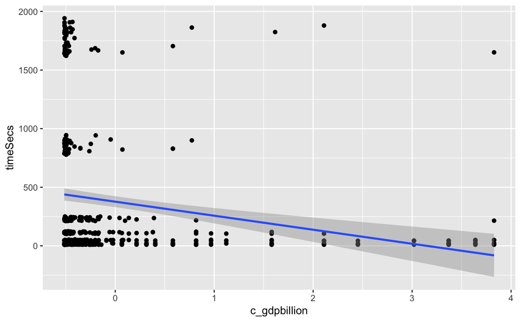

```r
 ggplot(data = track, aes(x=c_gdpbillion, y=timeSecs)) + geom_point() + stat_smooth(method = "lm")
```

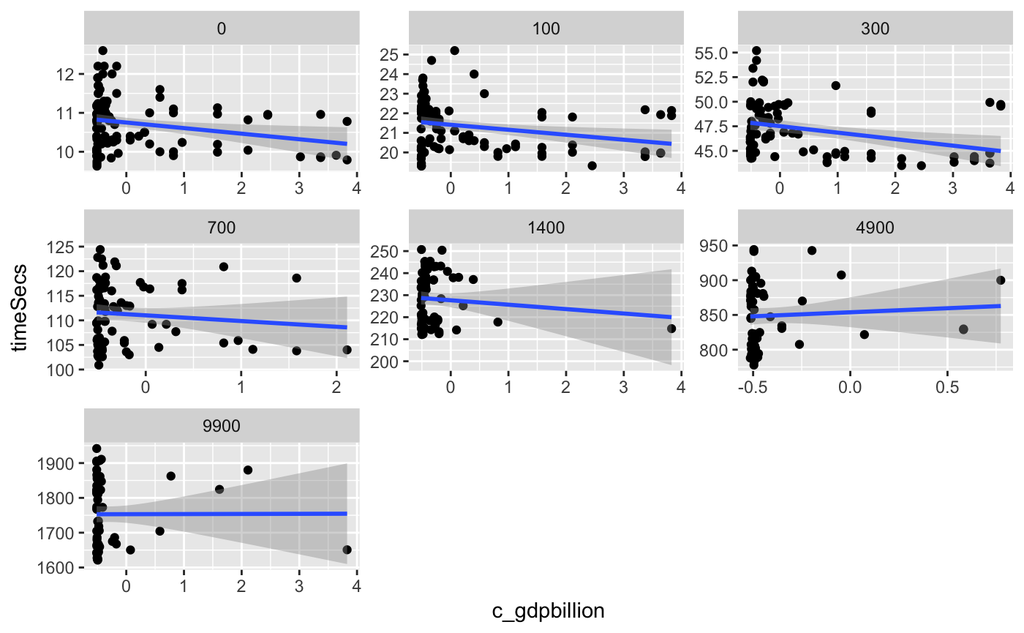

```r
 ggplot(data = track, aes(x=c_gdpbillion, y=timeSecs)) + geom_point() + stat_smooth(method = "lm") + facet_wrap(aes(dist100), scales = "free")
```

Events from the 100m to the 1500m have a negative relationship with time and gdp, BUT the distances with higher times have slightly positive or almost 0 slopes, which could be making the whole gdp coefficient positive. We will try including the interaction of dist x gdp.

### Model 9

```r
mod9 <- lme(data = track,
            fixed = timeSecs ~ dist100 + c_BMI + c_BMI*dist100 +
                               year1896 + sex +
                               sex*dist100 + c_gdpbillion + c_gdpbillion*dist100,
            random = ~ dist100|country2)
summary(mod9)
```

```
Linear mixed-effects model fit by REML
 Data: track
```

|  | AIC | BIC | logLik |
| --- | --- | --- | --- |
|  | 5345.162 | 5401.791 | -2659.581 |

```
Random effects:
 Formula: ~dist100 | country2
 Structure: General positive-definite, Log-Cholesky parametrization
            StdDev       Corr
(Intercept) 12.368407467 (Intr)
dist100      0.007146399 -0.94
Residual    20.639645552

Fixed effects: timeSecs ~ dist100 + c_BMI + c_BMI * dist100 + year1896 + sex +      sex * dist100 + c_gdpbillion + c_gdpbillion * dist100
```

|  | Value | Std.Error | DF | t-value | p-value |
| --- | --- | --- | --- | --- | --- |
| (Intercept) | 20.002170 | 4.451730 | 532 | 4.49312 | 0.0000 |
| dist100 | 0.171875 | 0.001495 | 532 | 114.99009 | 0.0000 |
| c_BMI | 4.109750 | 1.302003 | 532 | 3.15648 | 0.0017 |
| year1896 | -0.406194 | 0.042633 | 532 | -9.52773 | 0.0000 |
| sexW | 14.496656 | 2.812158 | 532 | 5.15499 | 0.0000 |
| c_gdpbillion | 7.341639 | 1.505467 | 532 | 4.87665 | 0.0000 |
| dist100:c_BMI | 0.001794 | 0.000481 | 532 | 3.72810 | 0.0002 |
| dist100:sexW | 0.019091 | 0.000887 | 532 | 21.51088 | 0.0000 |
| dist100:c_gdpbillion | -0.001505 | 0.000701 | 532 | -2.14656 | 0.0323 |

```
 Correlation:
                     (Intr) dst100 c_BMI  yr1896 sexW   c_gdpb d100:_B d100:W
dist100              -0.574
c_BMI                -0.090  0.087
year1896             -0.758  0.088 -0.043
sexW                 -0.032  0.088  0.457 -0.263
c_gdpbillion          0.561 -0.130 -0.119 -0.595 -0.021
dist100:c_BMI        -0.115  0.095 -0.452  0.186 -0.278 -0.068
dist100:sexW          0.027 -0.057 -0.232  0.085 -0.481  0.021  0.552
dist100:c_gdpbillion -0.175  0.160 -0.058  0.151 -0.018 -0.400  0.209   0.051

Standardized Within-Group Residuals:
        Min          Q1         Med          Q3         Max
-5.20198607 -0.43597692 -0.01434764  0.38412058  8.25926406

Number of Observations: 585
Number of Groups: 45
```

Running mod9 with lme4 instead of nlme

```r
lmer(data = track, timeSecs ~ dist100 + c_BMI + c_BMI*dist100 + year1896 + sex + sex*dist100 + c_gdpbillion + dist100*c_gdpbillion + (dist100|country2))
```

```
Some predictor variables are on very different scales: consider rescalingunable to evaluate scaled gradientModel failed to converge: degenerate  Hessian with 1 negative eigenvalues
```

```
Linear mixed model fit by REML ['lmerMod']
Formula: timeSecs ~ dist100 + c_BMI + c_BMI * dist100 + year1896 + sex +
    sex * dist100 + c_gdpbillion + dist100 * c_gdpbillion + (dist100 |      country2)
   Data: track
REML criterion at convergence: 5345.818
Random effects:
 Groups   Name        Std.Dev. Corr
 country2 (Intercept) 32.66876
          dist100      0.01385 -0.98
 Residual             20.17797
Number of obs: 585, groups:  country2, 45
Fixed Effects:
         (Intercept)               dist100                 c_BMI              year1896                  sexW
           24.300807              0.171782              3.936587             -0.451518             15.044073
        c_gdpbillion         dist100:c_BMI          dist100:sexW  dist100:c_gdpbillion
            8.565514              0.001834              0.019133             -0.001596
fit warnings:
Some predictor variables are on very different scales: consider rescaling
convergence code 0; 2 optimizer warnings; 0 lme4 warnings
```

We can see lmer is throwing up a lot of errors.

Playing with log dist and log time

```r
track <-  track %>% mutate(
                  logdist = log(dist),
                  logdist100 = logdist - log(100),
                  logtimeSecs = log(timeSecs),
                  logtimeMins = log(timeMins),
                  logBMI = log(BMI),
                  c_logBMI = scale(logBMI)[,1],
                  loggdpbillion = log(gdpbillion),
                  c_loggdpbillion = scale(loggdpbillion)[,1]
                  )
```

Running mod9 with logdist (with lmer)

```r
lmer(data = track, timeSecs ~ logdist100 + c_BMI + c_BMI*logdist100 + year1896 + sex + sex*logdist100 + c_gdpbillion + c_gdpbillion*logdist100+ (logdist100|country2))
```

```
Linear mixed model fit by REML ['lmerMod']
Formula: timeSecs ~ logdist100 + c_BMI + c_BMI * logdist100 + year1896 +
    sex + sex * logdist100 + c_gdpbillion + c_gdpbillion * logdist100 +      (logdist100 | country2)
   Data: track
REML criterion at convergence: 7891.89
Random effects:
 Groups   Name        Std.Dev. Corr
 country2 (Intercept) 624.2
          logdist100  206.5    -0.96
 Residual             190.5
Number of obs: 585, groups:  country2, 45
Fixed Effects:
            (Intercept)               logdist100                    c_BMI                 year1896                     sexW
               -615.452                  404.482                  106.686                   -1.278                  191.809
           c_gdpbillion         logdist100:c_BMI          logdist100:sexW  logdist100:c_gdpbillion
                -32.565                  -48.690                  -54.672                   48.281
```

lmer now gives no errors! The sign for the GDP coefficient is now negative, which makes more sense. The unusual issue now is that intercept is negative.

### Model 10

Same as previous lmer model but using lme and saving it as mod10

```r
mod10 <- lme(data = track,
            fixed = timeSecs ~ logdist100 + c_BMI + c_BMI*logdist100 +
                               year1896 + sex +
                               sex*logdist100 + c_gdpbillion + c_gdpbillion*logdist100,
            random = ~ logdist100|country2)
summary(mod10)
```

```
Linear mixed-effects model fit by REML
 Data: track
```

|  | AIC | BIC | logLik |
| --- | --- | --- | --- |
|  | 7917.89 | 7974.519 | -3945.945 |

```
Random effects:
 Formula: ~logdist100 | country2
 Structure: General positive-definite, Log-Cholesky parametrization
            StdDev   Corr
(Intercept) 624.1502 (Intr)
logdist100  206.4469 -0.96
Residual    190.5049

Fixed effects: timeSecs ~ logdist100 + c_BMI + c_BMI * logdist100 + year1896 +      sex + sex * logdist100 + c_gdpbillion + c_gdpbillion * logdist100
```

|  | Value | Std.Error | DF | t-value | p-value |
| --- | --- | --- | --- | --- | --- |
| (Intercept) | -615.4490 | 119.94842 | 532 | -5.130947 | 0.0000 |
| logdist100 | 404.4821 | 38.28289 | 532 | 10.565611 | 0.0000 |
| c_BMI | 106.6864 | 17.86605 | 532 | 5.971459 | 0.0000 |
| year1896 | -1.2779 | 0.48534 | 532 | -2.633003 | 0.0087 |
| sexW | 191.8102 | 38.67328 | 532 | 4.959761 | 0.0000 |
| c_gdpbillion | -32.5652 | 18.85753 | 532 | -1.726909 | 0.0848 |
| logdist100:c_BMI | -48.6901 | 7.90372 | 532 | -6.160400 | 0.0000 |
| logdist100:sexW | -54.6727 | 16.01728 | 532 | -3.413355 | 0.0007 |
| logdist100:c_gdpbillion | 48.2810 | 10.36712 | 532 | 4.657123 | 0.0000 |

```
 Correlation:
                        (Intr) lgd100 c_BMI  yr1896 sexW   c_gdpb l100:_B l100:W
logdist100              -0.891
c_BMI                    0.001  0.054
year1896                -0.366  0.036 -0.186
sexW                    -0.033  0.106  0.564 -0.232
c_gdpbillion             0.266 -0.103 -0.103 -0.548 -0.098
logdist100:c_BMI        -0.081  0.023 -0.756  0.237 -0.442 -0.024
logdist100:sexW          0.036 -0.095 -0.416  0.061 -0.750  0.119  0.498
logdist100:c_gdpbillion -0.036  0.111  0.108 -0.024  0.121 -0.589 -0.005  -0.107

Standardized Within-Group Residuals:
       Min         Q1        Med         Q3        Max
-2.3925558 -0.5634912 -0.1256192  0.4028348  5.1532978

Number of Observations: 585
Number of Groups: 45
```

For the 100m (logdist100 = 0), the predicted time for male athlete of average of everything is -615.45s. That’s not good.

Comparing models with dist and logdist

```r
AIC(mod9); AIC(mod10)
```

```
[1] 5345.162
[1] 7917.89
```

The AIC is much worse for the log(dist) model.

### Model 11

Trying log(time) as the response

```r
mod11 <- lme(data = track,
            fixed = logtimeSecs ~ logdist100 + c_BMI + c_BMI*logdist100 +
                               year1896 + sex +
                               sex*logdist100 + c_gdpbillion + c_gdpbillion*logdist100,
            random = ~ logdist100|country2)
summary(mod11)
```

```
Linear mixed-effects model fit by REML
 Data: track
```

|  | AIC | BIC | logLik |
| --- | --- | --- | --- |
|  | -1933.247 | -1876.618 | 979.6236 |

```
Random effects:
 Formula: ~logdist100 | country2
 Structure: General positive-definite, Log-Cholesky parametrization
            StdDev     Corr
(Intercept) 0.06341842 (Intr)
logdist100  0.01547263 -0.97
Residual    0.03921032

Fixed effects: logtimeSecs ~ logdist100 + c_BMI + c_BMI * logdist100 + year1896 +      sex + sex * logdist100 + c_gdpbillion + c_gdpbillion * logdist100
```

|  | Value | Std.Error | DF | t-value | p-value |
| --- | --- | --- | --- | --- | --- |
| (Intercept) | 2.4616189 | 0.015352790 | 532 | 160.33691 | 0.0000 |
| logdist100 | 1.1120519 | 0.003570038 | 532 | 311.49581 | 0.0000 |
| c_BMI | -0.0032275 | 0.003595938 | 532 | -0.89755 | 0.3698 |
| year1896 | -0.0015264 | 0.000092422 | 532 | -16.51593 | 0.0000 |
| sexW | 0.1176975 | 0.007770546 | 532 | 15.14662 | 0.0000 |
| c_gdpbillion | 0.0081033 | 0.003771490 | 532 | 2.14855 | 0.0321 |
| logdist100:c_BMI | -0.0018225 | 0.001543737 | 532 | -1.18055 | 0.2383 |
| logdist100:sexW | -0.0003421 | 0.003137697 | 532 | -0.10903 | 0.9132 |
| logdist100:c_gdpbillion | -0.0037983 | 0.001876714 | 532 | -2.02392 | 0.0435 |

```
 Correlation:
                        (Intr) lgd100 c_BMI  yr1896 sexW   c_gdpb l100:_B l100:W
logdist100              -0.826
c_BMI                   -0.013  0.113
year1896                -0.547  0.103 -0.191
sexW                    -0.064  0.211  0.556 -0.229
c_gdpbillion             0.403 -0.212 -0.106 -0.551 -0.110
logdist100:c_BMI        -0.106  0.028 -0.759  0.268 -0.442 -0.028
logdist100:sexW          0.060 -0.167 -0.415  0.054 -0.755  0.142  0.508
logdist100:c_gdpbillion -0.098  0.204  0.119  0.064  0.139 -0.628 -0.024  -0.157

Standardized Within-Group Residuals:
        Min          Q1         Med          Q3         Max
-2.53932746 -0.77973368  0.06844736  0.75072189  4.06989613

Number of Observations: 585
Number of Groups: 45
```

The predicted time for a male athlete’s 100m (and average of everything else) is e^(2.462) = 11.72s which is good. But now, BMI, dist x BMI, dist x sex are not statistically significant.

Comparing mod9 and mod11 (mod11 = mod9 but with logTime and logdist)

```r
AIC(mod9); AIC(mod11)
```

```
[1] 5345.162
[1] -1933.247
```

Questions: - Explain why we did logdist (lmer errors, very different scales) - How can we test/compare models once we do log transformations for both explanatory and responses variables? - Once we do logTime, AIC becomes negative. What do we do with that? - Once we do logTime, 3 variables become insignificant (1 main, 2 interactions) and we know at least the BMI variable should be significant. Does everything have to be log transformed? - Just general tips for dealing with transformations